# Final Assignment

Oscar Brück

06.03.2017

# Final Assignment

## Abstract

In this assignment, I will analyse how alcohol consumption and other phenomena affect school grades. For the analysis, I will use linear regression model and the MCA plot. According to the linear regression model, students studying more and students with no romantic relationships are more likely to have higher school grades. The MCA plot nicely validates the role of romantic relationships.

## Research Questions

Using the youth alcohol consumption data downloaded from the UCI Machine Learning Repository, I am going to study the variance of different variables using MCA and the effect of different variables to grades using linear regression.

My hypothesis is that high amount of ‘absences’, no ‘famsup’, low ‘studytime’ and bad ‘famrel’ correlates with a higher alcohol consumption

## Data Wrangling

The data wrangling are found [here] (https://github.com/obruck/IODS-project/blob/master/data/alc_data%20wrangling.R)

The data files “mat” and “por” have been joined by using common variables as identifiers. Then, duplicate answers have been omitted. Three new variables have been created. “alc_use” is the total weekly alcohol consumption, “edu” stands for female and male education and “high_use” corresponds to students abusing high alcohol amounts.

## Read and Explore the Data

```r
setwd("/Users/obruck/Desktop/Open data course/IODS-project/data/")
alc <- read.csv("alc.csv")
colnames(alc)
```

```
##  [1] "X"          "school"     "sex"        "age"        "address"
##  [6] "famsize"    "Pstatus"    "Medu"       "Fedu"       "Mjob"
## [11] "Fjob"       "reason"     "nursery"    "internet"   "guardian"
## [16] "traveltime" "studytime"  "failures"   "schoolsup"  "famsup"
## [21] "paid"       "activities" "higher"     "romantic"   "famrel"
## [26] "freetime"   "goout"      "Dalc"       "Walc"       "health"
## [31] "absences"   "G1"         "G2"         "G3"         "alc_use"
## [36] "high_use"   "edu"
```

```r
dim(alc)
```

```
## [1] 382  37
```

```r
str(alc)
```

```
## 'data.frame':    382 obs. of  37 variables:
##  $ X         : int  1 2 3 4 5 6 7 8 9 10 ...
##  $ school    : Factor w/ 2 levels "GP","MS": 1 1 1 1 1 1 1 1 1 1 ...
##  $ sex       : Factor w/ 2 levels "F","M": 1 1 1 1 1 2 2 1 2 2 ...
##  $ age       : int  18 17 15 15 16 16 16 17 15 15 ...
##  $ address   : Factor w/ 2 levels "R","U": 2 2 2 2 2 2 2 2 2 2 ...
##  $ famsize   : Factor w/ 2 levels "GT3","LE3": 1 1 2 1 1 2 2 1 2 1 ...
##  $ Pstatus   : Factor w/ 2 levels "A","T": 1 2 2 2 2 2 2 1 1 2 ...
##  $ Medu      : int  4 1 1 4 3 4 2 4 3 3 ...
##  $ Fedu      : int  4 1 1 2 3 3 2 4 2 4 ...
##  $ Mjob      : Factor w/ 5 levels "at_home","health",..: 1 1 1 2 3 4 3 3 4 3 ...
##  $ Fjob      : Factor w/ 5 levels "at_home","health",..: 5 3 3 4 3 3 3 5 3 3 ...
##  $ reason    : Factor w/ 4 levels "course","home",..: 1 1 3 2 2 4 2 2 2 2 ...
##  $ nursery   : Factor w/ 2 levels "no","yes": 2 1 2 2 2 2 2 2 2 2 ...
##  $ internet  : Factor w/ 2 levels "no","yes": 1 2 2 2 1 2 2 1 2 2 ...
```

[output cut: 23 more lines]

The data constitutes of 382 observations and 36 variables. They represent the correlation between alcohol usage and social, gender and study time attributes for each student.

Data Set Information:  
P. Cortez and A. Silva. Using Data Mining to Predict Secondary School Student Performance. In A. Brito and J. Teixeira Eds., Proceedings of 5th FUture BUsiness TEChnology Conference (FUBUTEC 2008) pp. 5-12, Porto, Portugal, April, 2008, EUROSIS, ISBN 978-9077381-39-7.

Attribute Information:  
1 school - student’s school (binary: ‘GP’ - Gabriel Pereira or ‘MS’ - Mousinho da Silveira)  
2 sex - student’s sex (binary: ‘F’ - female or ‘M’ - male)  
3 age - student’s age (numeric: from 15 to 22)  
4 address - student’s home address type (binary: ‘U’ - urban or ‘R’ - rural)  
5 famsize - family size (binary: ‘LE3’ - less or equal to 3 or ‘GT3’ - greater than 3)  
6 Pstatus - parent’s cohabitation status (binary: ‘T’ - living together or ‘A’ - apart)  
7 Medu - mother’s education (numeric: 0 - none, 1 - primary education (4th grade), 2 - 5th to 9th grade, 3 - secondary education or 4 - higher education) 8 Fedu - father’s education (numeric: 0 - none, 1 - primary education (4th grade), 2 - 5th to 9th grade, 3 - secondary education or 4 - higher education) 9 Mjob - mother’s job (nominal: ‘teacher’, ‘health’ care related, civil ‘services’ (e.g. administrative or police), ‘at_home’ or ‘other’)  
10 Fjob - father’s job (nominal: ‘teacher’, ‘health’ care related, civil ‘services’ (e.g. administrative or police), ‘at_home’ or ‘other’)  
11 reason - reason to choose this school (nominal: close to ‘home’, school ‘reputation’, ‘course’ preference or ‘other’)  
12 nursery - attended nursery school (binary: yes or no)  
13 internet - Internet access at home (binary: yes or no)  
14 guardian - student’s guardian (nominal: ‘mother’, ‘father’ or ‘other’)  
15 traveltime - home to school travel time (numeric: 1 - <15 min., 2 - 15 to 30 min., 3 - 30 min. to 1 hour, or 4 - >1 hour)  
16 studytime - weekly study time (numeric: 1 - <2 hours, 2 - 2 to 5 hours, 3 - 5 to 10 hours, or 4 - >10 hours)  
17 failures - number of past class failures (numeric: n if 1<=n<3, else 4)  
18 schoolsup - extra educational support (binary: yes or no)  
19 famsup - family educational support (binary: yes or no)  
20 paid - extra paid classes within the course subject (Math or Portuguese) (binary: yes or no)  
21 activities - extra-curricular activities (binary: yes or no)  
22 higher - wants to take higher education (binary: yes or no)  
23 romantic - with a romantic relationship (binary: yes or no)  
24 famrel - quality of family relationships (numeric: from 1 - very bad to 5 - excellent)  
25 freetime - free time after school (numeric: from 1 - very low to 5 - very high)  
26 goout - going out with friends (numeric: from 1 - very low to 5 - very high)  
27 Dalc - workday alcohol consumption (numeric: from 1 - very low to 5 - very high)  
28 Walc - weekend alcohol consumption (numeric: from 1 - very low to 5 - very high)  
29 health - current health status (numeric: from 1 - very bad to 5 - very good)  
30 absences - number of school absences (numeric: from 0 to 93)  
31 G1 - first period grade (numeric: from 0 to 20)  
32 G2 - second period grade (numeric: from 0 to 20)  
33 G3 - final grade (numeric: from 0 to 20, output target)  
34 alc_use - average of ‘Dalc’ and ‘Walc’  
35 high_use - TRUE if ‘alc_use’ is higher than 2 and FALSE otherwise

```r
summary(alc)
```

```
##        X          school   sex          age        address famsize
##  Min.   :  1.00   GP:342   F:198   Min.   :15.00   R: 81   GT3:278
##  1st Qu.: 96.25   MS: 40   M:184   1st Qu.:16.00   U:301   LE3:104
##  Median :191.50                    Median :17.00
##  Mean   :191.50                    Mean   :16.59
##  3rd Qu.:286.75                    3rd Qu.:17.00
##  Max.   :382.00                    Max.   :22.00
##  Pstatus      Medu            Fedu             Mjob           Fjob
##  A: 38   Min.   :0.000   Min.   :0.000   at_home : 53   at_home : 16
##  T:344   1st Qu.:2.000   1st Qu.:2.000   health  : 33   health  : 17
##          Median :3.000   Median :3.000   other   :138   other   :211
##          Mean   :2.806   Mean   :2.565   services: 96   services:107
##          3rd Qu.:4.000   3rd Qu.:4.000   teacher : 62   teacher : 31
##          Max.   :4.000   Max.   :4.000
##         reason    nursery   internet    guardian     traveltime
##  course    :140   no : 72   no : 58   father: 91   Min.   :1.000
##  home      :110   yes:310   yes:324   mother:275   1st Qu.:1.000
##  other     : 34                       other : 16   Median :1.000
##  reputation: 98                                    Mean   :1.448
##                                                    3rd Qu.:2.000
##                                                    Max.   :4.000
##    studytime        failures      schoolsup famsup     paid     activities
##  Min.   :1.000   Min.   :0.0000   no :331   no :144   no :205   no :181
##  1st Qu.:1.000   1st Qu.:0.0000   yes: 51   yes:238   yes:177   yes:201
##  Median :2.000   Median :0.0000
##  Mean   :2.037   Mean   :0.2016
##  3rd Qu.:2.000   3rd Qu.:0.0000
##  Max.   :4.000   Max.   :3.0000
##  higher    romantic      famrel         freetime        goout
##  no : 18   no :261   Min.   :1.000   Min.   :1.00   Min.   :1.000
##  yes:364   yes:121   1st Qu.:4.000   1st Qu.:3.00   1st Qu.:2.000
##                      Median :4.000   Median :3.00   Median :3.000
##                      Mean   :3.937   Mean   :3.22   Mean   :3.113
##                      3rd Qu.:5.000   3rd Qu.:4.00   3rd Qu.:4.000
##                      Max.   :5.000   Max.   :5.00   Max.   :5.000
##       Dalc            Walc           health         absences
##  Min.   :1.000   Min.   :1.000   Min.   :1.000   Min.   : 0.0
##  1st Qu.:1.000   1st Qu.:1.000   1st Qu.:3.000   1st Qu.: 1.0
##  Median :1.000   Median :2.000   Median :4.000   Median : 3.0
##  Mean   :1.482   Mean   :2.296   Mean   :3.573   Mean   : 4.5
##  3rd Qu.:2.000   3rd Qu.:3.000   3rd Qu.:5.000   3rd Qu.: 6.0
##  Max.   :5.000   Max.   :5.000   Max.   :5.000   Max.   :45.0
##        G1              G2              G3           alc_use
##  Min.   : 2.00   Min.   : 4.00   Min.   : 0.00   Min.   :1.000
##  1st Qu.:10.00   1st Qu.:10.00   1st Qu.:10.00   1st Qu.:1.000
##  Median :12.00   Median :12.00   Median :12.00   Median :1.500
##  Mean   :11.49   Mean   :11.47   Mean   :11.46   Mean   :1.889
##  3rd Qu.:14.00   3rd Qu.:14.00   3rd Qu.:14.00   3rd Qu.:2.500
##  Max.   :18.00   Max.   :18.00   Max.   :18.00   Max.   :5.000
##   high_use            edu
##  Mode :logical   Min.   :1.000
##  FALSE:268       1st Qu.:4.000
##  TRUE :114       Median :6.000
##  NA's :0         Mean   :5.372
##                  3rd Qu.:7.000
##                  Max.   :8.000
```

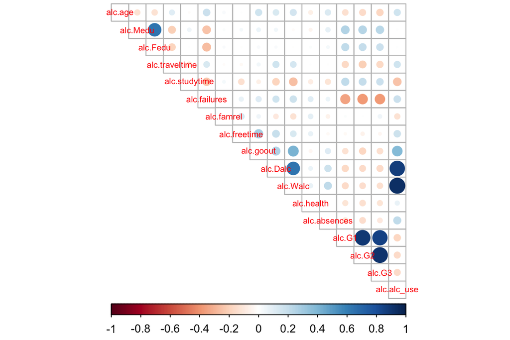

```r
library(dplyr)
library(corrplot)
alc_num <- data.frame(alc$age, alc$Medu, alc$Fedu, alc$traveltime, alc$studytime, alc$failures, alc$famrel, alc$freetime, alc$goout, alc$Dalc, alc$Walc, alc$health, alc$absences, alc$G1, alc$G2, alc$G3, alc$alc_use)
corrplot(cor(alc_num), method="circle", type="upper", cl.pos="b", tl.pos="d", tl.cex=0.6)
```

The data is composed of 198 females and 184 males. Normality of data is determined based on suffient n number (here n=382 is observed as sufficient) and on how close median and mean values are of each others. Variables “age”, “Medu”, “studytime”, “failures”, “famrel”, “freetime”, “goout”, “Dalc”, “Walc”, “G1”, “G2”, “G3”, “alc_use” are normally distributed. In addition, varibles “school”, “sex”, “address”, “famsize”, “Pstatus”, “Mjob”, “Fjob”, “reason”, “nursery”, “internet”, “guardian”, “schoolsup”, “famsup”, “paid”, “activities”, “higher”, “romantic”, “high_use” are binomial or multinomial.

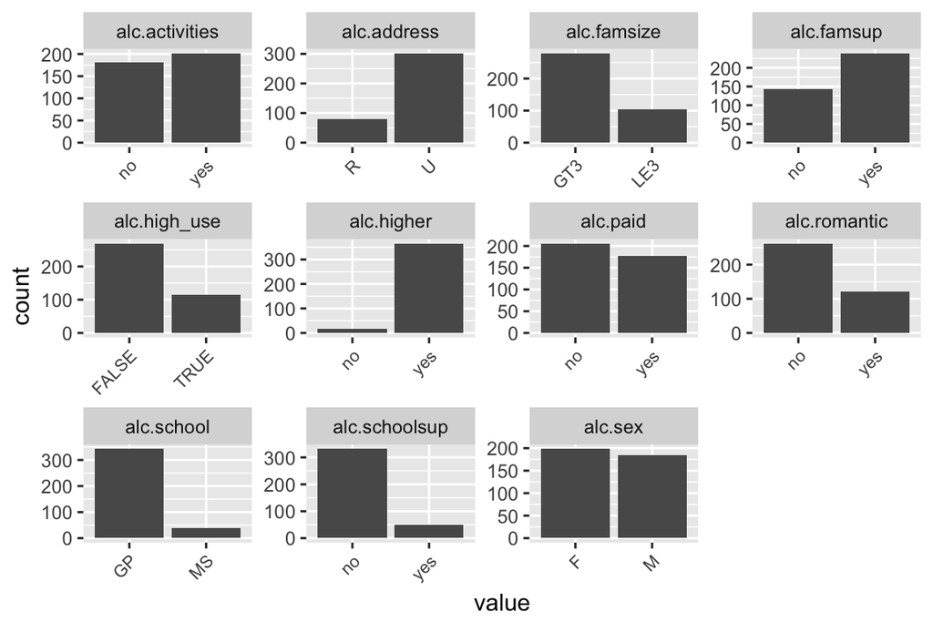

```r
library(dplyr)
library(ggplot2)
library(tidyr)
library(stringr)
alc_nom <- data.frame(alc$school, alc$sex, alc$address, alc$famsize, alc$paid, alc$schoolsup, alc$famsup, alc$activities, alc$higher, alc$romantic, alc$high_use)
gather(alc_nom) %>% ggplot(aes(value)) + facet_wrap("key", scales = "free") +  geom_bar() + theme(axis.text.x = element_text(angle = 45, hjust = 1, size = 8))
```

Then, we explore the impact of the education of mothers, fathers and their summed education to alcohol use and final grade. Parent education doesn’t seem to affect alcohol grade but have a clear positive correlation with higher mean grades.

```r
alc %>% group_by(Medu) %>% summarise(count = n(), mean_alc_use = mean(alc_use))
```

```
## # A tibble: 5 × 3
##    Medu count mean_alc_use
##   <int> <int>        <dbl>
## 1     0     3     2.166667
## 2     1    51     1.950980
## 3     2    98     1.739796
## 4     3    95     2.021053
## 5     4   135     1.874074
```

```r
alc %>% group_by(Fedu) %>% summarise(count = n(), mean_alc_use = mean(alc_use))
```

```
## # A tibble: 5 × 3
##    Fedu count mean_alc_use
##   <int> <int>        <dbl>
## 1     0     2     1.000000
## 2     1    77     1.941558
## 3     2   105     1.895238
## 4     3    99     1.787879
## 5     4    99     1.959596
```

```r
alc %>% group_by(edu) %>% summarise(count = n(), mean_alc_use = mean(alc_use))
```

```
## # A tibble: 8 × 3
##     edu count mean_alc_use
##   <int> <int>        <dbl>
## 1     1     2     1.000000
## 2     2    36     1.958333
## 3     3    39     1.884615
## 4     4    68     1.933824
## 5     5    41     1.768293
## 6     6    63     1.888889
## 7     7    58     1.775862
## 8     8    75     1.993333
```

```r
alc %>% group_by(Medu) %>% summarise(count = n(), mean_grade = mean(G3))
```

```
## # A tibble: 5 × 3
##    Medu count mean_grade
##   <int> <int>      <dbl>
## 1     0     3   12.66667
## 2     1    51   10.09804
## 3     2    98   10.79592
## 4     3    95   11.49474
## 5     4   135   12.40000
```

```r
alc %>% group_by(Fedu) %>% summarise(count = n(), mean_grade = mean(G3))
```

```
## # A tibble: 5 × 3
##    Fedu count mean_grade
##   <int> <int>      <dbl>
## 1     0     2   13.50000
## 2     1    77   10.07792
## 3     2   105   11.56190
## 4     3    99   11.72727
## 5     4    99   12.11111
```

```r
alc %>% group_by(edu) %>% summarise(count = n(), mean_grade = mean(G3))
```

```
## # A tibble: 8 × 3
##     edu count mean_grade
##   <int> <int>      <dbl>
## 1     1     2  13.500000
## 2     2    36   9.861111
## 3     3    39  10.307692
## 4     4    68  10.867647
## 5     5    41  11.560976
## 6     6    63  12.063492
## 7     7    58  12.120690
## 8     8    75  12.226667
```

## Statistical Methods

Linear regression is a statistical method to predict a continuous variable (dependent varaible) with one or multiple variables (independent variables). If only one explanatory variable is used, the model is called simple linear regression. Otherwise, the process is called multiple linear regression. Linear regression takes into account the multicollinearity of indenpendent models and computes their “true” correlation coefficient to the dependent variable. Eventually, one can make a formula y = b1x1 + … + bnxn + C, where y = response variable (dependent variable), x = covariates, b = correlation coefficient of covariates, C = error term.

Multiple correspondence analysis (MCA) is a visualisation method to analyse categorical data and the connections between different variables and their values. The data is transposed onto a two-dimensional plot where the x-axis and y-axis represent the components explaining the most of the variance of the data. Then, the values of the selected variable are distributed on the plot based on their correlation with the principal components and other variables. Unlike PCA or LDA, MCA compares the different types of values of different categorical variables and not the exact values of each observations.

## Results

### Linear Regression Analysis

First let’s run a linear regression analysis where the final grade is the response variable and gender, tendency to go out with friends, the number of absences, alcohol consumption, family educational support, studytime and romantic relationships are the independent variables.

```r
alc$studytime <- factor(alc$studytime)
m <- lm(G3 ~ sex + goout + absences + alc_use + famsup + studytime + romantic, data = alc)
summary(m)
```

```
##
## Call:
## lm(formula = G3 ~ sex + goout + absences + alc_use + famsup +
##     studytime + romantic, data = alc)
##
## Residuals:
##      Min       1Q   Median       3Q      Max
## -11.5079  -1.8658   0.2236   2.1942   7.2735
##
## Coefficients:
##             Estimate Std. Error t value Pr(>|t|)
## (Intercept) 12.09832    0.68053  17.778  < 2e-16 ***
## sexM         0.52857    0.36391   1.452 0.147207
## goout       -0.28159    0.16077  -1.751 0.080691 .
## absences    -0.01752    0.03153  -0.556 0.578758
## alc_use     -0.27792    0.19608  -1.417 0.157210
## famsupyes   -0.07760    0.34674  -0.224 0.823046
## studytime2   0.90464    0.41559   2.177 0.030127 *
## studytime3   1.94795    0.57101   3.411 0.000717 ***
## studytime4   1.57705    0.72135   2.186 0.029421 *
## romanticyes -0.77491    0.36009  -2.152 0.032042 *
## ---
## Signif. codes:  0 '***' 0.001 '**' 0.01 '*' 0.05 '.' 0.1 ' ' 1
##
## Residual standard error: 3.218 on 372 degrees of freedom
## Multiple R-squared:  0.077,  Adjusted R-squared:  0.05467
## F-statistic: 3.448 on 9 and 372 DF,  p-value: 0.0004245
```

```r
OR <- coef(m) %>% exp
CI <- confint(m) %>% exp
cbind(OR, CI)
```

```
##                       OR        2.5 %       97.5 %
## (Intercept) 1.795706e+05 4.710642e+04 6.845268e+05
## sexM        1.696507e+00 8.294443e-01 3.469956e+00
## goout       7.545849e-01 5.500615e-01 1.035154e+00
## absences    9.826307e-01 9.235547e-01 1.045485e+00
## alc_use     7.573586e-01 5.150550e-01 1.113652e+00
## famsupyes   9.253378e-01 4.679389e-01 1.829833e+00
## studytime2  2.471031e+00 1.091375e+00 5.594774e+00
## studytime3  7.014305e+00 2.282198e+00 2.155838e+01
## studytime4  4.840670e+00 1.171881e+00 1.999528e+01
## romanticyes 4.607442e-01 2.269591e-01 9.353457e-01
```

### MCA

```r
attach(alc)
alc$G3cat[G3 <= 10] <- "Low grade"
alc$G3cat[G3 > 10 & G3 <= 14] <- "Intermediate grade"
alc$G3cat[G3 > 14] <- "High grade"
detach(alc)
str(alc)
```

```
## 'data.frame':    382 obs. of  38 variables:
##  $ X         : int  1 2 3 4 5 6 7 8 9 10 ...
##  $ school    : Factor w/ 2 levels "GP","MS": 1 1 1 1 1 1 1 1 1 1 ...
##  $ sex       : Factor w/ 2 levels "F","M": 1 1 1 1 1 2 2 1 2 2 ...
##  $ age       : int  18 17 15 15 16 16 16 17 15 15 ...
##  $ address   : Factor w/ 2 levels "R","U": 2 2 2 2 2 2 2 2 2 2 ...
##  $ famsize   : Factor w/ 2 levels "GT3","LE3": 1 1 2 1 1 2 2 1 2 1 ...
##  $ Pstatus   : Factor w/ 2 levels "A","T": 1 2 2 2 2 2 2 1 1 2 ...
##  $ Medu      : int  4 1 1 4 3 4 2 4 3 3 ...
##  $ Fedu      : int  4 1 1 2 3 3 2 4 2 4 ...
##  $ Mjob      : Factor w/ 5 levels "at_home","health",..: 1 1 1 2 3 4 3 3 4 3 ...
##  $ Fjob      : Factor w/ 5 levels "at_home","health",..: 5 3 3 4 3 3 3 5 3 3 ...
##  $ reason    : Factor w/ 4 levels "course","home",..: 1 1 3 2 2 4 2 2 2 2 ...
##  $ nursery   : Factor w/ 2 levels "no","yes": 2 1 2 2 2 2 2 2 2 2 ...
##  $ internet  : Factor w/ 2 levels "no","yes": 1 2 2 2 1 2 2 1 2 2 ...
```

[output cut: 24 more lines]

#### Run MCA

```r
library(FactoMineR)
alc_mca <- data.frame(alc$G3cat, alc$romantic, alc$high_use, alc$sex, alc$activities)
mca <- MCA(alc_mca, graph = FALSE)
summary(mca)
```

```
##
## Call:
## MCA(X = alc_mca, graph = FALSE)
##
##
## Eigenvalues
##                        Dim.1   Dim.2   Dim.3   Dim.4   Dim.5   Dim.6
## Variance               0.253   0.226   0.208   0.195   0.173   0.146
## % of var.             21.067  18.812  17.344  16.229  14.386  12.163
## Cumulative % of var.  21.067  39.878  57.222  73.451  87.837 100.000
##
## Individuals (the 10 first)
##                       Dim.1    ctr   cos2    Dim.2    ctr   cos2    Dim.3
## 1                  | -0.192  0.038  0.040 |  0.707  0.580  0.544 | -0.457
## 2                  | -0.192  0.038  0.040 |  0.707  0.580  0.544 | -0.457
## 3                  |  0.308  0.098  0.078 |  0.468  0.254  0.180 | -0.013
## 4                  | -0.601  0.374  0.320 | -0.087  0.009  0.007 |  0.853
## 5                  | -0.366  0.139  0.161 |  0.357  0.147  0.153 | -0.071
## 6                  |  0.103  0.011  0.013 | -0.679  0.535  0.563 |  0.171
## 7                  |  0.138  0.020  0.022 | -0.065  0.005  0.005 | -0.084
## 8                  | -0.192  0.038  0.040 |  0.707  0.580  0.544 | -0.457
## 9                  | -0.207  0.044  0.028 | -0.340  0.134  0.075 | -0.878
## 10                 |  0.103  0.011  0.013 | -0.679  0.535  0.563 |  0.171
##                       ctr   cos2
## 1                   0.263  0.227 |
## 2                   0.263  0.227 |
## 3                   0.000  0.000 |
## 4                   0.915  0.644 |
## 5                   0.006  0.006 |
## 6                   0.037  0.036 |
## 7                   0.009  0.008 |
## 8                   0.263  0.227 |
## 9                   0.970  0.501 |
## 10                  0.037  0.036 |
##
## Categories (the 10 first)
##                        Dim.1     ctr    cos2  v.test     Dim.2     ctr
## High grade         |  -0.876  10.799   0.166  -7.954 |  -0.848  11.348
## Intermediate grade |  -0.010   0.003   0.000  -0.170 |  -0.196   1.520
## Low grade          |   0.428   5.425   0.110   6.462 |   0.637  13.478
```

[output cut: 11 more lines]

```
## alc.romantic_no      0.036  -3.684 |  -0.483  15.303   0.503 -13.840 |
## alc.romantic_yes     0.036   3.684 |   1.041  33.010   0.503  13.840 |
## FALSE                0.015  -2.357 |  -0.040   0.105   0.004  -1.183 |
## TRUE                 0.015   2.357 |   0.093   0.247   0.004   1.183 |
## F                    0.251   9.774 |   0.015   0.011   0.000   0.303 |
## M                    0.251  -9.774 |  -0.016   0.012   0.000  -0.303 |
## alc.activities_no    0.530  14.215 |  -0.307   4.280   0.085  -5.679 |
##
## Categorical variables (eta2)
##                      Dim.1 Dim.2 Dim.3
## alc.G3cat          | 0.205 0.297 0.449 |
## alc.romantic       | 0.054 0.036 0.503 |
## alc.high_use       | 0.602 0.015 0.004 |
## alc.sex            | 0.401 0.251 0.000 |
## alc.activities     | 0.002 0.530 0.085 |
```

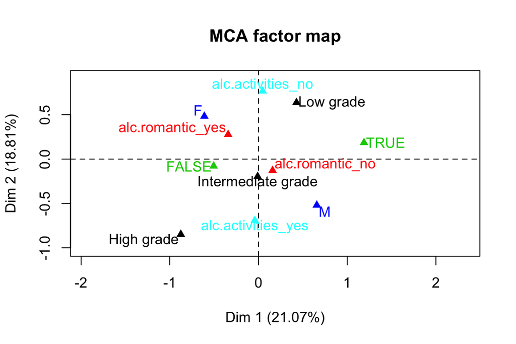

```r
plot(mca, invisible=c("ind"), habillage="quali")
```

## Conclusions and Discussion

According to the linear regression model, students studying more and students with no romantic relationships are more likely to have higher school grades. Interestingly, the optimal studytime is between 5-10 hours/week. The adjusted R-squared value is 0.055 so the model explains only 5.5% of the variance of school grades. This is partly due to the high amount of variables included in the model. Probably other variables have an impact on school grades as well but their effect is reduced due to multicollinearity.

In the MCA plot, we can see that the two principal components (or dimensions) explain 21.1% and 18.8% of total variance. High school grade is located in the lower left quandrant (negative correlation with both principal components), intermediate grade near origo (little correlation) and low grades in the upper right quandrant (positive correlation with both principal components). Extracurricular activities (“alc.activies_yes”), low alcohol consumption (“FALSE”) and lack of romantic relationships (“alc.romantic_no”) correlate with higher school grades. On the other hand, gender (“M” and “F”) have no effect. The exact numeric correlations with the principal components can be seen the summary of the MCA analysis.

In this case, validating either method is quite challenging as there are no additional validation cohort. First, also studytime was included in the MCA plot, but the plot did not look aesthetic and therefore it was left out. On the other hand, the MCA plot nicely validates the results of the linear regression model emphasizing the negative role of romantic relationships to school grades. Luckily, life is more than school grades :)